# Métodos de suavizado

Técnicas de Smoothing aplicadas a Series Temporales de Precios de Acciones

Enfoque Estadístico del Aprendizaje - Universidad de Buenos Aires

18 December 2023

A continuación instalaremos el paquete **quantmod**, necesario para obtener los valores históricos de una acción:

```r
if (!require("quantmod")) install.packages("quantmod")
```

La información es obtenida a partir de Yahoo Finance.Se debe especificar el periodo de tiempo que se quiere analizar. El resultado es una tabla con los precios de apertura y cierre del mercado, minimo y máximo alcanzado para cada día dentro del periodo especificado; además de otra información como el volumen de transacciones realizadas.

```r
library(quantmod)
# Símbolo de la acción que se desea obtener (por ejemplo, "AAPL" para Apple)
symbol <- "GOOGL"

# Especifica el periodo deseado (por ejemplo, desde el 1 de enero de 2021
#hasta el 31 de diciembre de 2021)
start_date <- "2023-07-01"
end_date <- "2023-12-18"

# Descarga la información de la acción para el periodo especificado
stock <- getSymbols(symbol, src = "yahoo", from = start_date, to = end_date, auto.assign = F)

# Muestra las primeras filas de los datos
head(stock)
```

```
##            GOOGL.Open GOOGL.High GOOGL.Low GOOGL.Close GOOGL.Volume
## 2023-07-03     119.24     120.19    118.82      119.90     14467900
## 2023-07-05     119.24     122.61    119.23      121.75     27584800
## 2023-07-06     119.80     120.30    118.40      120.11     24745200
## 2023-07-07     120.10     121.05    119.40      119.48     21692600
## 2023-07-10     118.30     118.31    116.14      116.45     35315200
## 2023-07-11     116.29     117.71    115.35      117.14     23078800
##            GOOGL.Adjusted
## 2023-07-03         119.90
## 2023-07-05         121.75
## 2023-07-06         120.11
## 2023-07-07         119.48
## 2023-07-10         116.45
## 2023-07-11         117.14
```

## 0.1 Graficos de la variación del precio

**quantmod** incluye una función para realizar este tipo de graficos en donde se incluye un histograma con el volumen de transacciones. Este gráfico se conoce como *gráfico de velas* y resume toda información relacionada con el precio del activo: el cuerpo de la vela marca los valores de apertura y cierre del mercado mientras que las mechas superiores e inferiores marcan el mínimo y el máximo alcanzado durante el periodo analizado. Típicamente los colores verde y rojo indican que el precio de cierre fue mayor o menor que el precio de apertura, respectivamente.

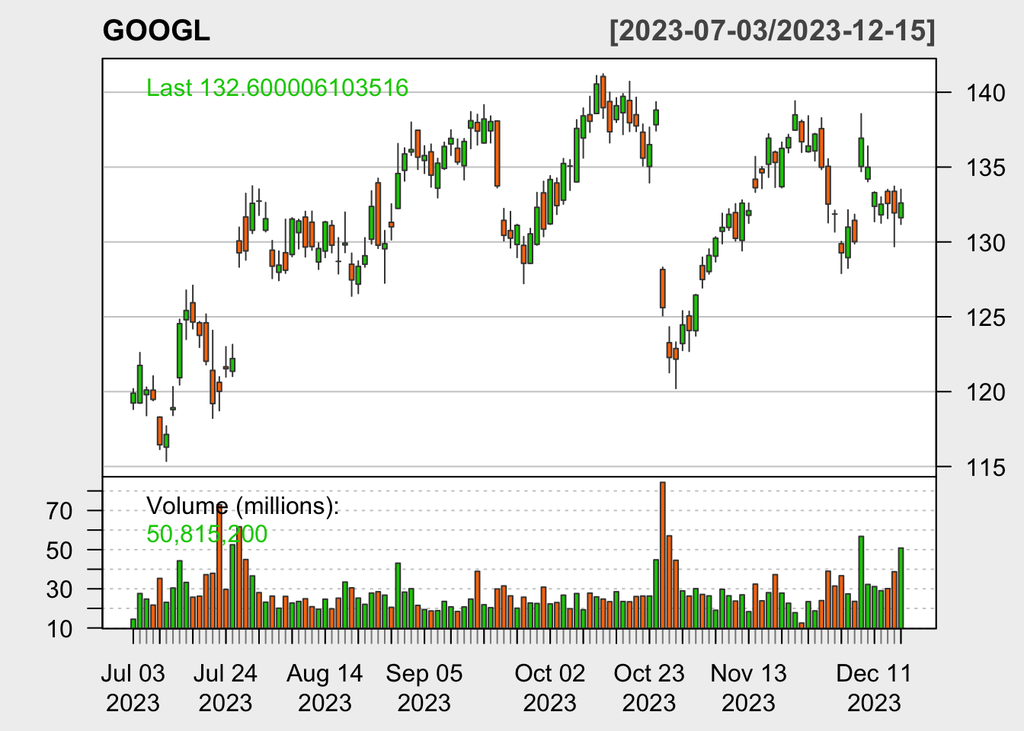

```r
chartSeries(stock, theme = "white", name = "GOOGL")
```

Si bien se puede agregar medias móviles a los gráficos generados con la función *chartSeries()*, pasaremos a realizarlos con ggplot teniendo en cuenta solamente el precio de cierre del activo:

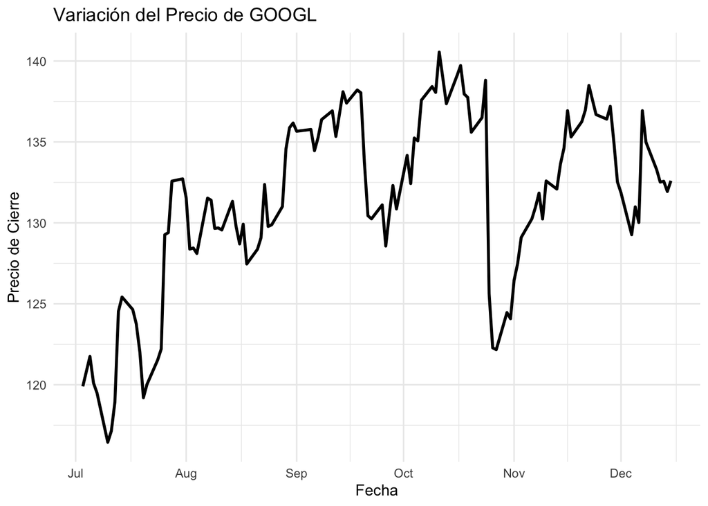

```r
library(ggplot2)
library(tidyverse)
stock_data <- as.data.frame(stock)
#Cambio los nombres de las columnas
colnames(stock_data) <- unlist(lapply(strsplit(colnames(stock_data), "\\."), function(x){x[2]}))
#columna con la información del tiempo
stock_data$time = rownames(stock_data) %>% as.POSIXct()

#Plot
ggplot(stock_data) +
  geom_line(aes(x = time, y = Close), linewidth = 1, linetype = "solid") +
  labs(title = paste("Variación del Precio de GOOGL"),
      x = "Fecha",
      y = "Precio de Cierre") +
  theme_minimal()
```

## 0.2 Media Movil Simple (SMA)

Comparemos el resultado de calcular medias móviles simples tomando diferente tamaño de ventana: 5, 20 y 50

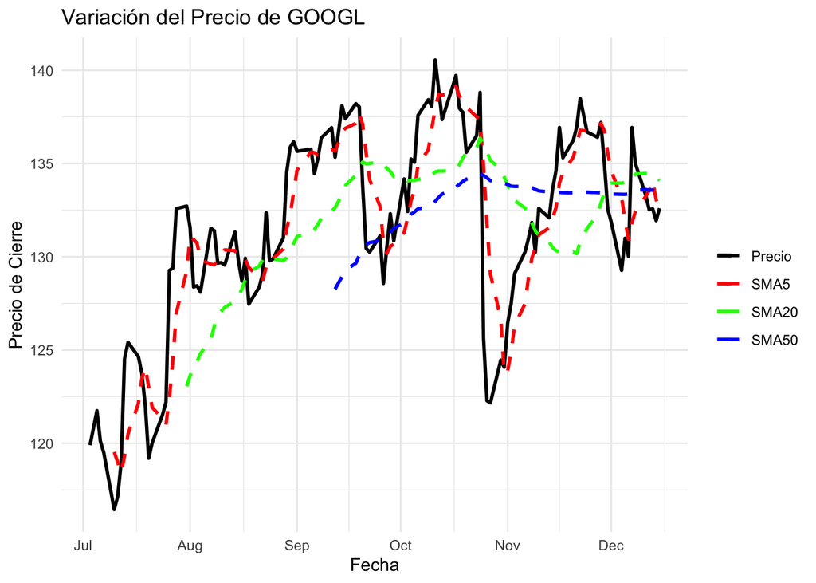

```r
stock_data$sma5  <- SMA(Cl(stock_data), n = 5)
stock_data$sma20 <- SMA(Cl(stock_data), n = 20)
stock_data$sma50 <- SMA(Cl(stock_data), n = 50)

ggplot(stock_data) +
  geom_line(aes(x = time, y = Close, colour = "Precio"), linewidth = 1, linetype = "solid") +
  geom_line(aes(x = time, y = sma5, colour = "SMA5"), linewidth = 1, linetype = "dashed") +
  geom_line(aes(x = time, y = sma20, colour = "SMA20"), linewidth = 1, linetype = "dashed") +
  geom_line(aes(x = time, y = sma50, colour = "SMA50"), linewidth = 1, linetype = "dashed") +
  labs(title = paste("Variación del Precio de GOOGL"),
       x = "Fecha",
       y = "Precio de Cierre") +
  scale_colour_manual("",
                      breaks = c("Precio", "SMA5", "SMA20", "SMA50"),
                      values = c("black", "red", "green", "blue")) +
  theme_minimal()
```

## 0.3 Media Movil Exponencial (EMA)

De forma similar, podemos graficar EMA’s con distinto tamaño de ventana

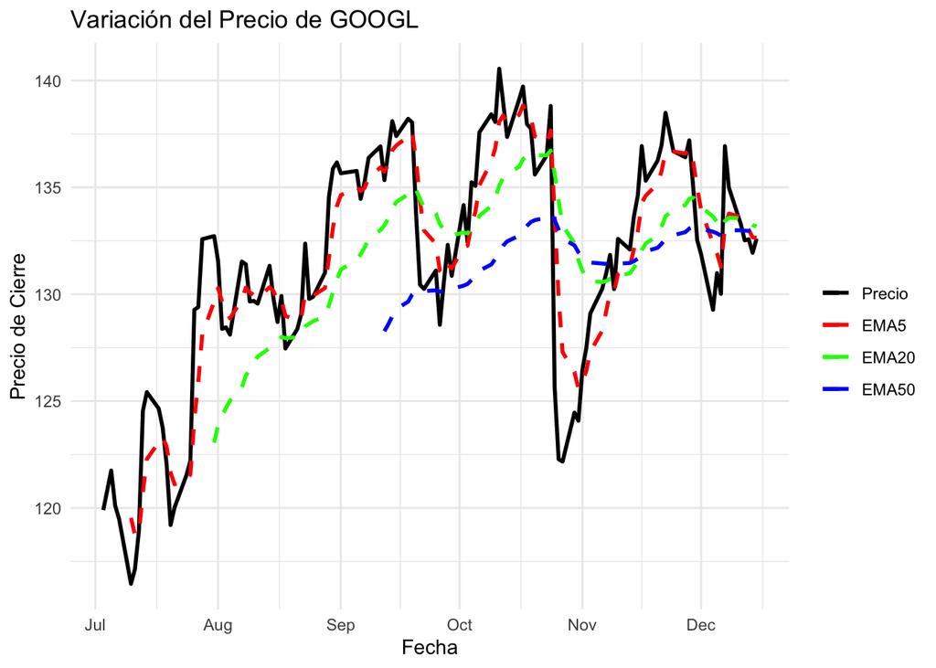

```r
stock_data$ema5  <- EMA(Cl(stock_data), n = 5)
stock_data$ema20 <- EMA(Cl(stock_data), n = 20)
stock_data$ema50 <- EMA(Cl(stock_data), n = 50)

ggplot(stock_data) +
  geom_line(aes(x = time, y = Close, colour = "Precio"), linewidth = 1, linetype = "solid") +
  geom_line(aes(x = time, y = ema5, colour = "EMA5"), linewidth = 1, linetype = "dashed") +
  geom_line(aes(x = time, y = ema20, colour = "EMA20"), linewidth = 1, linetype = "dashed") +
  geom_line(aes(x = time, y = ema50, colour = "EMA50"), linewidth = 1, linetype = "dashed") +
  labs(title = paste("Variación del Precio de GOOGL"),
       x = "Fecha",
       y = "Precio de Cierre") +
  scale_colour_manual("",
                      breaks = c("Precio", "EMA5", "EMA20", "EMA50"),
                      values = c("black", "red", "green", "blue")) +
  theme_minimal()
```

Por último, comparemos las SMA y las EMA utilizando la misma ventana en ambos casos:

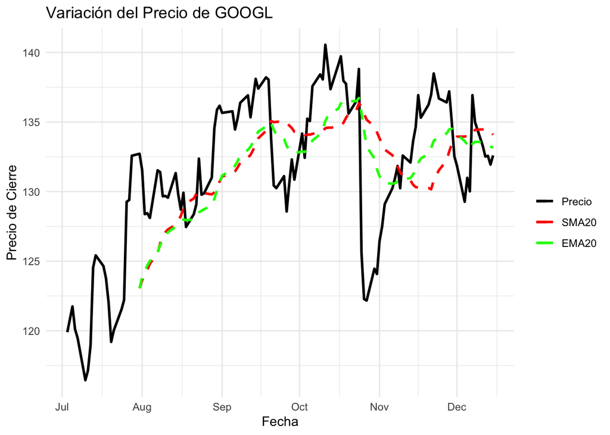

```r
ggplot(stock_data) +
  geom_line(aes(x = time, y = Close, colour = "Precio"), linewidth = 1, linetype = "solid") +
  geom_line(aes(x = time, y = sma20, colour = "SMA20"), linewidth = 1, linetype = "dashed") +
  geom_line(aes(x = time, y = ema20, colour = "EMA20"), linewidth = 1, linetype = "dashed") +
  labs(title = paste("Variación del Precio de GOOGL"),
       x = "Fecha",
       y = "Precio de Cierre") +
  scale_colour_manual("",
                      breaks = c("Precio", "SMA20", "EMA20"),
                      values = c("black", "red", "green")) +
  theme_minimal()
```

Podemos ver que ante una misma ventana temporal, la EMA responde de forma más rápida a los cambios que la SMA.

## 0.4 LOESS

Para aplicar la técnica de smoothing LOESS, podemos utilizar *geom_smooth()*. Con el parámetro *span* podemos regular el grado de suavizado.

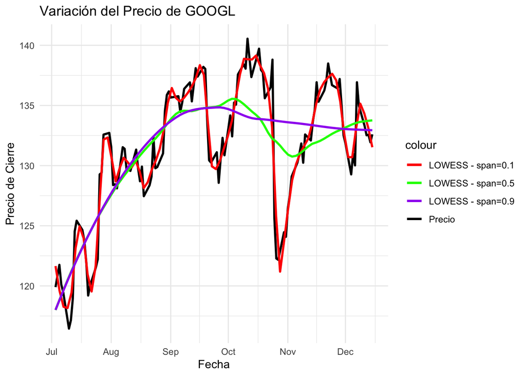

```r
ggplot(stock_data) +
  geom_line(aes(x = time, y = Close, colour = "Precio"), linewidth = 1, linetype = "solid") +
  geom_smooth(aes(x = time, y = Close, colour = "LOWESS - span=0.1"),
              method = "loess", span=0.1,se = FALSE) +
  geom_smooth(aes(x = time, y = Close, colour = "LOWESS - span=0.5"),
              method = "loess", span=0.5,se = FALSE) +
  geom_smooth(aes(x = time, y = Close, colour = "LOWESS - span=0.9"),
              method = "loess", span=0.9,se = FALSE) +
  labs(title = paste("Variación del Precio de GOOGL"),
       x = "Fecha",
       y = "Precio de Cierre")+
  scale_color_manual(values = c("Precio" = "black",
                                "LOWESS - span=0.1" = "red",
                                "LOWESS - span=0.5" = "green",
                                "LOWESS - span=0.9" = "purple")) +
  theme_minimal()
```